# Capitulo 2: Introduccion a la Estadistica Inferencial

Dereck Amesquita

6/4/2021

# La regresión Lineal

Podemos medir el efecto lineal que tiene una variable sobre otra con la regresión lineal.
$$y = a+bx$$
En el capitulo de estadística inferencial se abordaran los mínimos cuadrados ordinarios que nos ayudaran a obtener el valor de b.

```r
data="https://raw.githubusercontent.com/dereckamesquita/Learning-Before-Estadistica/main/datasets/bodyfat.txt"
datos=read.table(data, header = TRUE)
datosn=datos[,c(2,4)]
names(datosn)=c("Grasa","Peso")
str(datosn)
```

```
## 'data.frame':    252 obs. of  2 variables:
##  $ Grasa: num  12.3 6.1 25.3 10.4 28.7 20.9 19.2 12.4 4.1 11.7 ...
##  $ Peso : num  154 173 154 185 184 ...
```

```r
# Regresion
#lm(y~x) #Esto se lee como formula es decir: Y de X o y=ƒ(X)
#Alt+159 = ƒ
regre1=lm(Peso~Grasa, data=datosn)
lm(datosn$Peso~datosn$Grasa)
```

```
##
## Call:
## lm(formula = datosn$Peso ~ datosn$Grasa)
##
## Coefficients:
##  (Intercept)  datosn$Grasa
##      137.738         2.151
```

## Graficando la regresion lineal

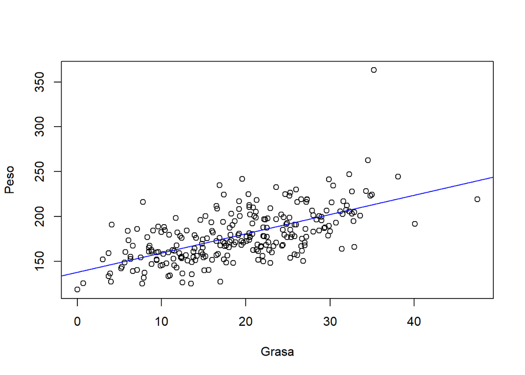

```r
plot(datosn)
abline(regre1, col="blue")
```

## El coeficiente de determinacion R2

```r
summary(regre1) # Nos arroja la inform acion mas importante de nuestra regresion
```

```
##
## Call:
## lm(formula = Peso ~ Grasa, data = datosn)
##
## Residuals:
##     Min      1Q  Median      3Q     Max
## -46.799 -14.999  -3.469  11.860 149.709
##
## Coefficients:
##             Estimate Std. Error t value Pr(>|t|)
## (Intercept) 137.7375     3.6684   37.55   <2e-16 ***
## Grasa         2.1507     0.1756   12.25   <2e-16 ***
## ---
## Signif. codes:  0 '***' 0.001 '**' 0.01 '*' 0.05 '.' 0.1 ' ' 1
##
## Residual standard error: 23.28 on 250 degrees of freedom
## Multiple R-squared:  0.3751, Adjusted R-squared:  0.3726
## F-statistic:   150 on 1 and 250 DF,  p-value: < 2.2e-16
```

```r
summary(regre1)$r.squared #Nos arroja solo el R2
```

```
## [1] 0.3750509
```

## Escalas Logaritmicas

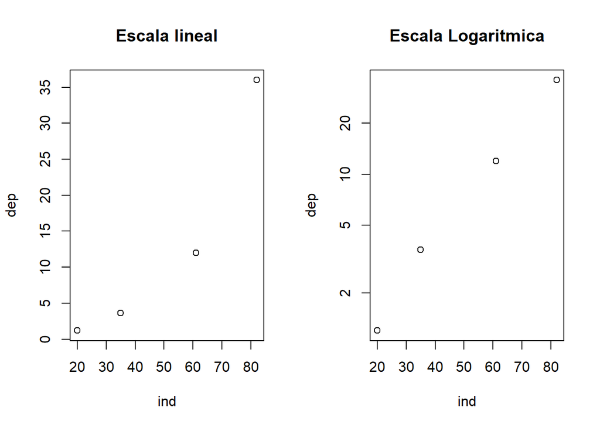

```r
dep=c(1.2,3.6,12,36)
ind=c(20,35,61,82)
#Graficos
par(mfrow = c(1, 2))#Juntar dos plots
plot(ind,dep, main = "Escala lineal")
plot(ind,dep, log="y", main = "Escala Logaritmica")
```

```r
regrelognivel=lm(log10(dep)~ind)
summary(regrelognivel)
```

```
##
## Call:
## lm(formula = log10(dep) ~ ind)
##
## Residuals:
##         1         2         3         4
## -0.054845  0.074624 -0.005094 -0.014686
##
## Coefficients:
##              Estimate Std. Error t value Pr(>|t|)
## (Intercept) -0.329510   0.076575  -4.303   0.0500 *
## ind          0.023177   0.001394  16.626   0.0036 **
## ---
## Signif. codes:  0 '***' 0.001 '**' 0.01 '*' 0.05 '.' 0.1 ' ' 1
##
## Residual standard error: 0.0664 on 2 degrees of freedom
## Multiple R-squared:  0.9928, Adjusted R-squared:  0.9892
## F-statistic: 276.4 on 1 and 2 DF,  p-value: 0.003598
```

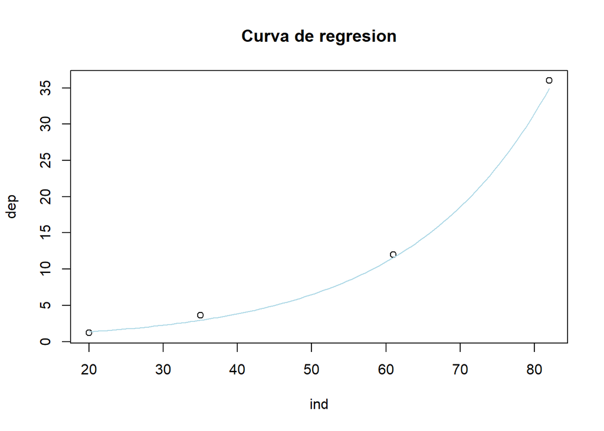

```r
#Grafico
plot(ind,dep,main="Curva de regresion")
curve(1.054^x*0.468, add=TRUE, col="lightblue")
```

## Regresiones potenciales

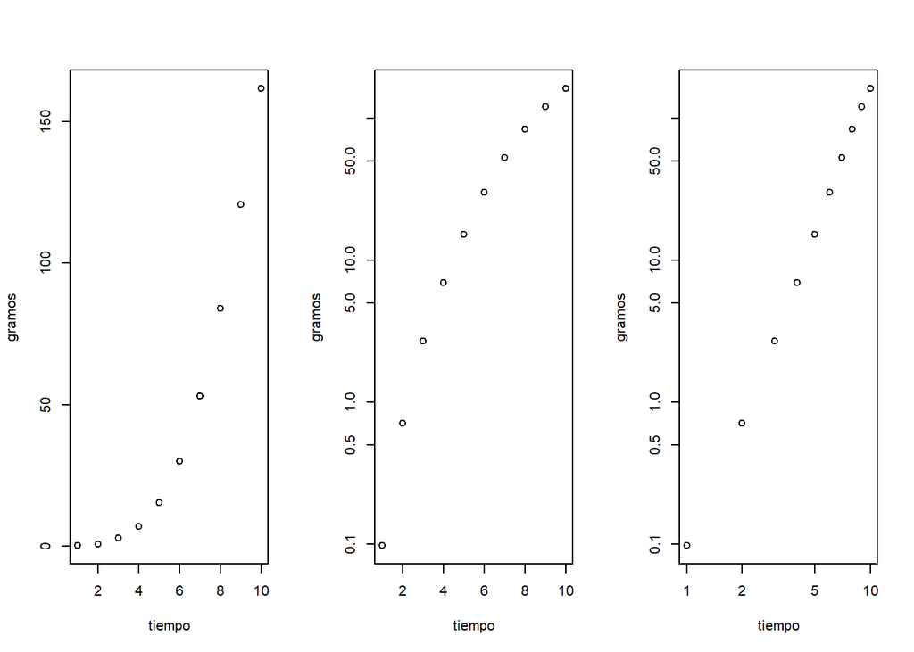

```r
tiempo = 1:10
gramos = c(0.097,0.709,2.698,6.928,15.242,29.944,52.902,83.903,120.612,161.711)
d.f = data.frame(tiempo,gramos)
# Graficas
par(mfrow= c(1,3))
plot(d.f)
plot(d.f, log="y")
plot(d.f, log="xy")
```

```r
par(mfrow= c(1,1))
```

# Las distribuciones de probabilidad

## Los experimentos aleatorios

-Un experimento es un acto en el cual no conoces el resultado. -Un suceso elemental son los posibles resultados. Cara o cruz. -El espacio muestral es el conjunto de todos los sucesos elementales.

## Variable Aleatoria

Es una variable que toma distintos valores. El dominio de la variable aleatoria son todos los números que puede tomar. $p(X=a) = p(\{\omega\in\Omega \ |\ X(\omega) = a\})$

Se lee: La probabilidad de que la variable aleatoria tome el valor a, es la probabilidad de que el suceso (w) que pertenece al espacio muestral, tal que X de w sea igual a a.

- $p(a< X< b) = p(\{\omega\in\Omega \ |\ a< X(\omega) < b\})$
- $p(X\in A) = p(\{\omega\in\Omega \ |\ X(\omega)\in A\})$

## La función de distribución

Funcion de distribucion de la v.a. X. Es una funcion:
$$F:\mathbb{R}\longrightarrow [0,1]$$

dado por:
$$F(x)=p(X\le x)$$

Que se lee como el valor acumulado $F(x)$ es igual a la suma de todas las probabilidades anteriores a x $p(X\le x)$

### Ejemplo tirar un dado de 6 caras

Queremos saber la probabilidad de sacar 5. Es decir $F(5)$ igual a la probabilidad de que la v.a. tome el valor de 5, $p(5\le x)$

# Variable Aleatoria Discreta

-Una v.a es discreta cuando $X:\Omega\longrightarrow\mathbb{R}$ y $D_x$ es finito, es decir el dominio de x es un subconjunto de los naturales. La v.a. solo toma los valores de su dominio. Ejemplo las caras de un dado, ya que este es un número finito.

-Funcion de densidad es la funcion $f:\mathbb{R}\longrightarrow[0,1]$, definido por
$$f(x)=p(X=x)$$

Se concluye que $f(x)=0$ si $x\not\in D_x$. A lo cual llegamos que la funcion de densidad es: $f: D_x\longrightarrow[0,1]$

### Esperanza

Dado $f: D_x\longrightarrow[0,1]$, entonces podemos decir que la esperanza es la multiplicacion de cada elemento $x$ dentro de $D_x$ por su probabilidad.
$$E(X)=\sum_{x\in D_x}x \cdot f(x)$$
Esta version es muy parecida a la media vista como la sumatoria de la frecuencia relativa por cada valor. Esto se vio en un documento pasado. Tambien se ve como:

$$E(g(X))=\sum_{x\in D_x}g(x) \cdot f(x)$$
Podemos calcular la esperanza de $x^2$
$$E(X^2)=\sum_{x\in D_x}x^2 \cdot f(x)$$

### Varianza

Como vimos en capitulos pasados, la varianza es la diferencia de la media de X al cuadrado menos el cuadrado de la media de x.En terminos se esperanza es similar, se puede demostrar desde:
$$Var(X)=E((X-E(X))^2)$$
Se entiende como la diferencia de X respecto a su valor esperado elevado al cuadrado. Se resuelve como:
$$=E(X^2-2XE(X)+E(X)^2)$$
$$=E(X^2)-E(2XE(X))+E(E(X)^2)$$
El valor esperado en $E(E(X)^2)$ seguira siendo $E(X)^2$
$$=E(X^2)-2E(X)E(X)+E(X)^2$$
$$=E(X^2)-2[E(X)]^2+E(X)^2$$
$$Var(X)=E(X^2)-[E(X)]^2$$
Tambien lo podemos entender como: Si $X$ es una v.a. discreta y $g:D_X\longrightarrow \mathbb{R}$ una función,
$$Var(g(X))=E((g(X)-E(g(X)))^2)=E(g(X)^2)-[E(g(X))]^2$$
En este caso $g$ es una funcion cualquiera con un dominio de dicha variable aleatoria discreta.

### Desviacion tipica

Se entiende como:
$$\sigma(X)=\sqrt{Var(X)}$$
Tambien se puede entender como:
$$\sigma(g(X))=\sqrt{Var(g(X))}$$

# Distribuciones de probabilidad aplicadas

Cualquier variable aleatoria (va) se puede trabajar con las funciones dva, pva, qva y rva.

-**dva** nos dara la función de densidad o probabilidad de la variable. Su remplazo en python es pmf o pdf.

-**pva** nos dara la funcion de distribucion $F(x)$ de la variable aleatoria. Su remplazo en python es cdf.

-**qva** nos dara el cuartil de la variable. El valor minimo donde $F(x)\geq p$. Su remplazo en python es ppf.

-**rva** genera obserbacion con la distribucion de la variable aleatoria. Su remplazo en python es rvs.

En R usamos Rlab y en python usamos scipy.stats

## Distribucion de Bernoulli

Si X mide el numero de casos a favor o de exito, si se realiza un experimento (1 en caso de exito y 0 en caso de fracaso). Si X sigue una distribucion de Bernoulli con parametro p(probabilidad de exito) utilizaremos:
$$X\sim \text{Be}(p)$$

### Elementos importantes

Donde la **probabilidad** de fracaso es $q=1-p$.

El **dominio** de $X$ es $X(\Omega)=\{0,1\}$. Tambien se puede entender como $D_X = \{0,1\}$. Donde el dominio solo abarca 0 y 1, entendido como fracaso y exito.

La **función de probabilidad** esta dada por:
$$f(k)=p^k(1-p)^{1-k}= \left\{
\begin{array}{rl}
p & \text{si } k=1
\\ 1-p & \text{si } k=0
\\ 0 & \text{en cualquier otro caso}
\end{array}
\right.$$

-Donde si $k=1$ entonces $f(k)=p^1(1-p)^{1-1}=f(k)=p^1(1-p)^{0}\longrightarrow f(k)=p$

-Donde si $k=0$ entonces $f(k)=p^0(1-p)^{1-0}=f(k)=p^0(1-p)^{1}=1-p\longrightarrow f(k)=q$

-Donde si toma otro valor sera cero, puesto que se trata de una distribución discreta.

La **función de distribución acumulada** esta dada por:

$$F(k) = \left\{
\begin{array}{rl}
0 & \text{si } k<0
\\ 1-p & \text{si } 0\le k<1
\\ 1 & \text{si } k\ge 1
\end{array}
\right.$$
Para los calculos de la media procedemos a remplazar $k$ por $x$ La media de la distribucion de Bernoulli es:
$$E(X)=0*P(X=0)+1*P(X=1) \longrightarrow E(X)=P(X=1)=p$$
La varianza de la distribucion de Benoulli es:
$$Var(X)=E(X^2)-E(X)^2$$
$$E(X^2)=\sum_{x=0}^1 x^2p^xq^{1-x}$$
$$E(X^2)=0^2p^0q^{1-0}+1^2p^1q^{1-1}$$
$$E(X^2)=p^1q^{1-1}=p$$

Por lo tanto podemos retomar:
$$Var(X)=p-p^2=p(1-p)$$

### Corriendo la distribucion de Bernoulli

**Funcion de densidad o de probabilidad**
$$f(x)=p^x(1-p)^{1-x}, k={0,1}$$
Suponiendo que tenemos una moneda trucada con probabilidad de exito de 0.7. Es decir $X\sim \text{Be}\ (p=0.7)$

```r
library(Rlab)
dbern(0,0.7) #dbern trabaja la distribucion de Bernoulli
```

```
## [1] 0.3
```

```r
dbern(1,0.7)
```

```
## [1] 0.7
```

```r
pbern(0,0.7)
```

```
## [1] 0.3
```

```r
pbern(1,0.7)
```

```
## [1] 1
```

```r
qbern(0.5,0.7)
```

```
## [1] 1
```

```r
qbern(0.25,0.7)
```

```
## [1] 0
```

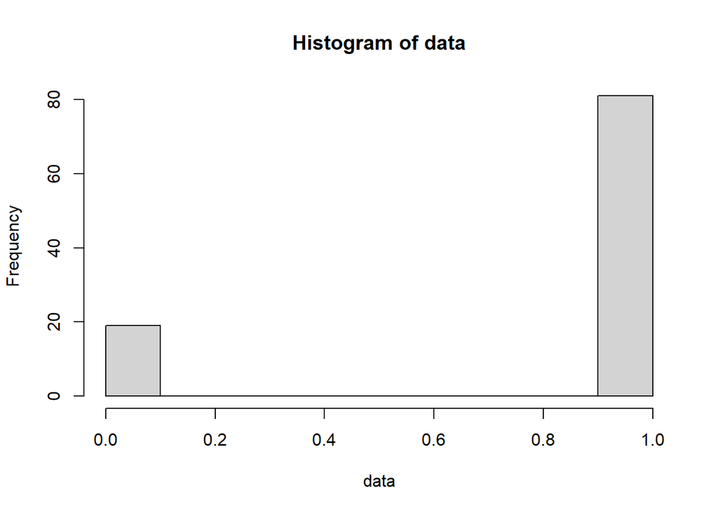

```r
rbern(100,0.7)->data
hist(data)
```

Nos arroja que la probabilidad de sacar 0 es de 0.3 y la de sacar 1 es de 0.7

## Distribucion Binomial

Si $X$ es una V.A. la cual mide el numero de exitos donde se realizan $n$ ensayos de Bernoulli independientes entre si, entonces $X$ se distribuye de la siguiente forma.
$$X\sim \text{B}(n,p)$$

El dominio sera $D_X = \{0,1,2,\dots,n\}$ La funcion de densidad estara dada por:
$$f(k) = {n\choose k}p^k(1-p)^{n-k}$$
- La **función de distribución** (probabilidad acumulada) vendrá dada por
$$F(x) = \left\{
\begin{array}{cl}
0 & \text{si } x<0
\\ \sum_{k=0}^xf(k) & \text{si } 0\le x<n
\\ 1 & \text{si } x\ge n
\end{array}
\right.$$

- **Esperanza** $E(X) = np$
- **Varianza** $Var(X) = npq$

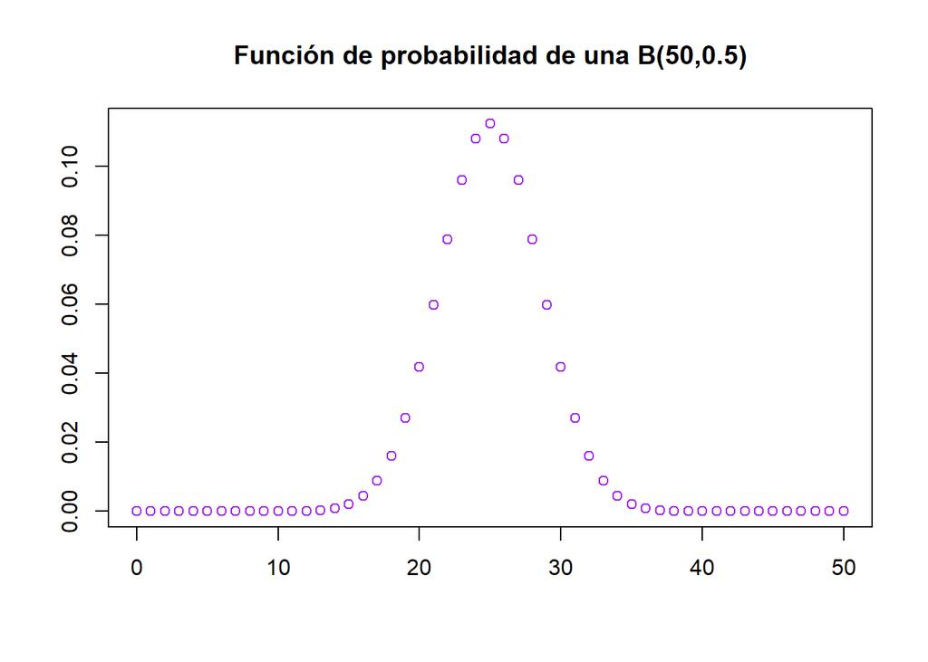

```r
plot(0:50,dbinom(0:50,50,0.5),col = "purple", xlab = "", ylab = "", main = "Función de probabilidad de una B(50,0.5)")
```

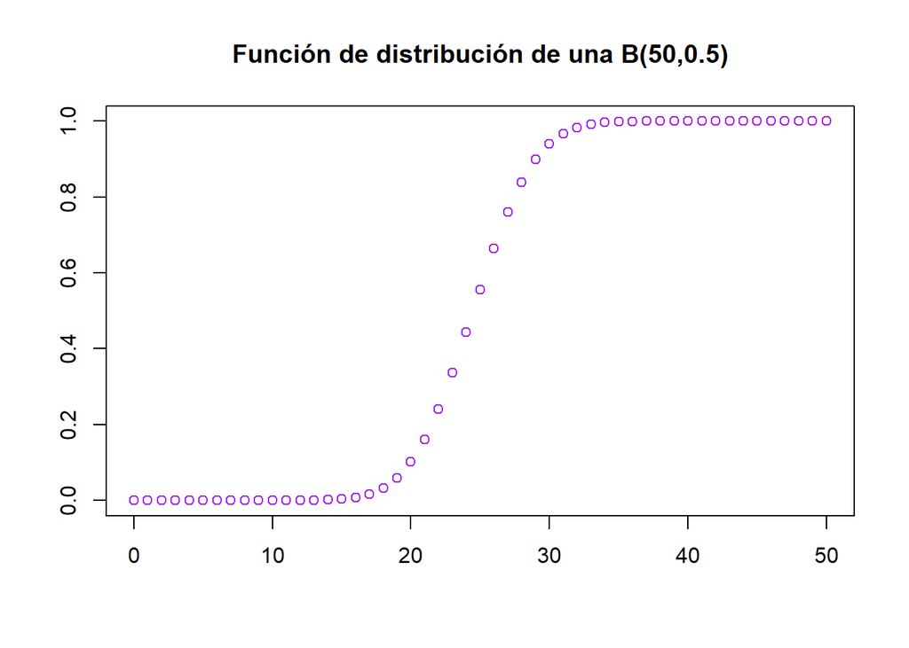

```r
plot(0:50, pbinom(0:50,50,0.5),col = "purple", xlab = "", ylab = "", main = "Función de distribución de una B(50,0.5)", ylim = c(0,1))
```

### Ejemplo

Sea $X = B(30, 0.6)$

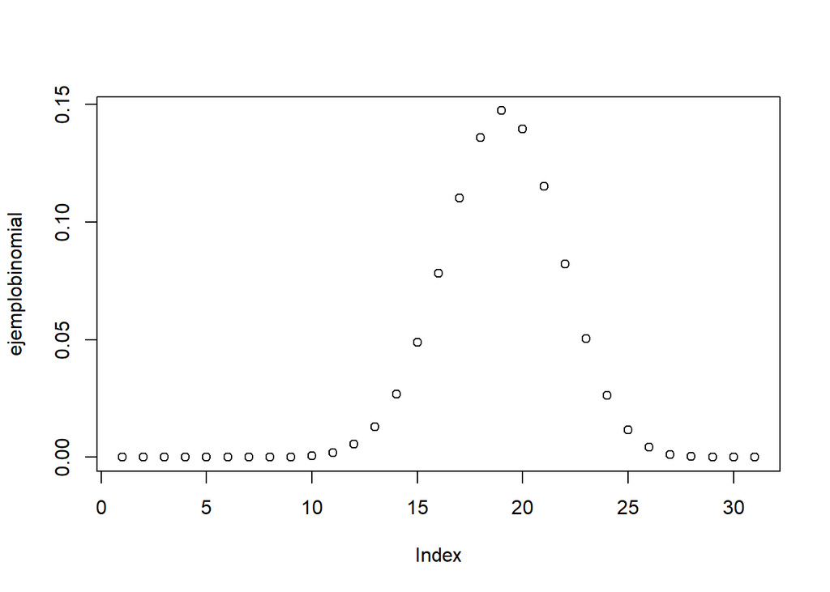

```r
n<-30
p<-0.6
x<-0:30
#FUncion de densidad
ejemplobinomial<-dbinom(x, n, p)
plot(ejemplobinomial)
```

```r
media_ejemplobinomial<-n*p
var_ejemplobinomial<-n*p*(1-p)
media_ejemplobinomial
```

```
## [1] 18
```

```r
var_ejemplobinomial
```

```
## [1] 7.2
```

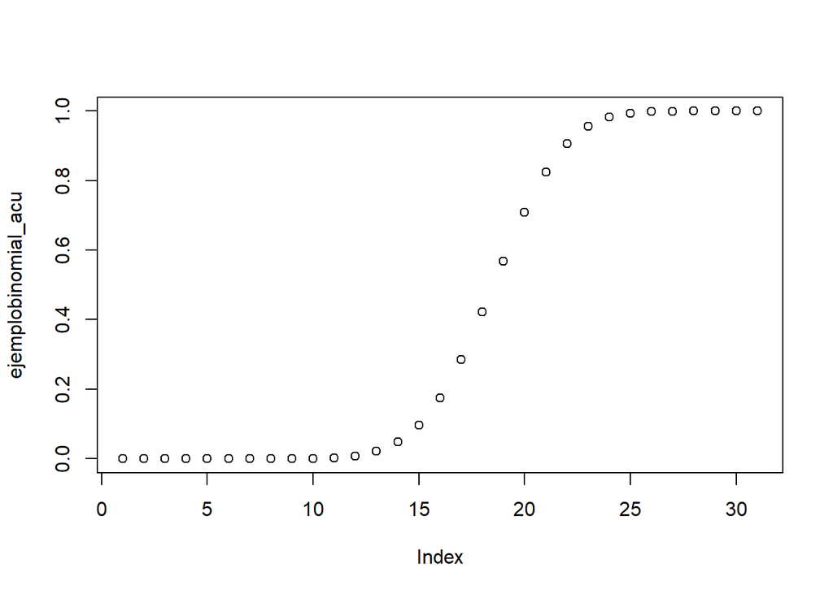

```r
#Funcion de distribucion
ejemplobinomial_acu<-pbinom(x, n, p)
plot(ejemplobinomial_acu)
```

```r
qbinom(0.5,n,p)
```

```
## [1] 18
```

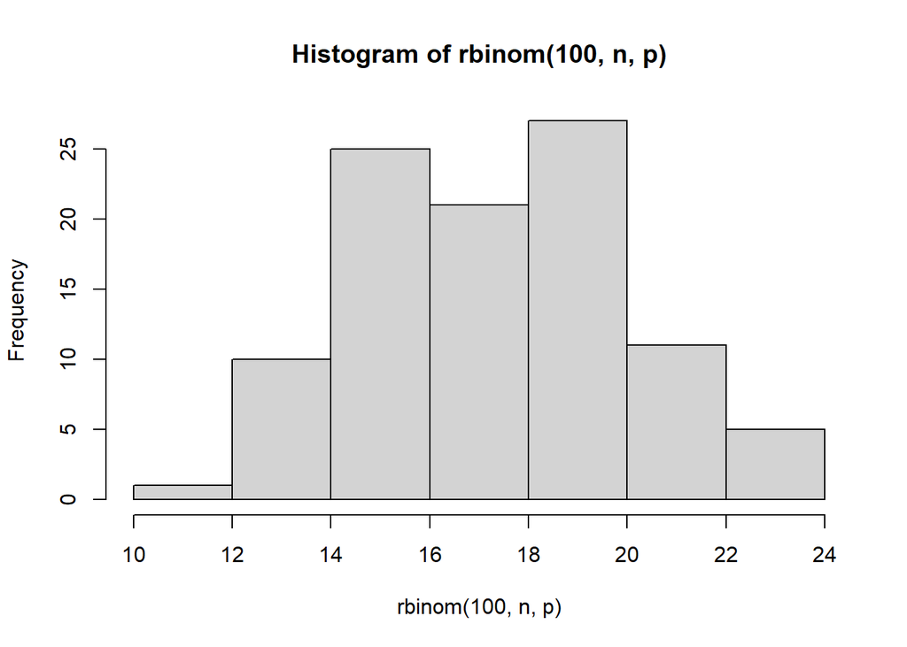

```r
hist(rbinom(100,n,p)) #Parece tener sesgo cuando hacemos 100 repeticiones
```

El 50% esta debajo de 18.

## Distribucion Geometrica

Si X es una variable que se encarga de medir el “numero de repeticiones independientes del experimento hasta conseguir exito” se distribuira de la siguiente forma.
$$X\sim \text{Ge}(p)$$
- El **dominio** de $X$ será $D_X= \{0,1,2,\dots\}$ o bien $D_X = \{1,2,\dots\}$ en función de si empieza en 0 o en 1, respectivamente

- La **función de probabilidad o densidad** vendrá dada por
  $$f(k) = (1-p)^{k}p \qquad\text{ si empieza en 0}$$

$$f(k) = (1-p)^{k-1}p \qquad\text{ si empieza en 1}$$
- La **función de distribución** vendrá dada por
$$F(x) = \left\{
\begin{array}{cl}
0 & \text{si } x<0
\\ 1-(1-p)^{k+1} & \text{si } k\le x<k+1,\ k\in\mathbb{N}
\end{array}
\right.$$

- **Esperanza** $E(X) = \frac{1-p}{p}$ si empieza en 0 y E$(X) = \frac{1}{p}$ si empieza en 1
- **Varianza** $Var(X) = \frac{1-p}{p^2}$
- Propiedad de la falta de memoria. Si $X$ es una v.a. $\text{Ge}(p)$, entonces,
  $$p\{X\ge m+n:\ X\ge n\} = p\{X\ge m\}\ \forall m,n=0,1,\dots$$

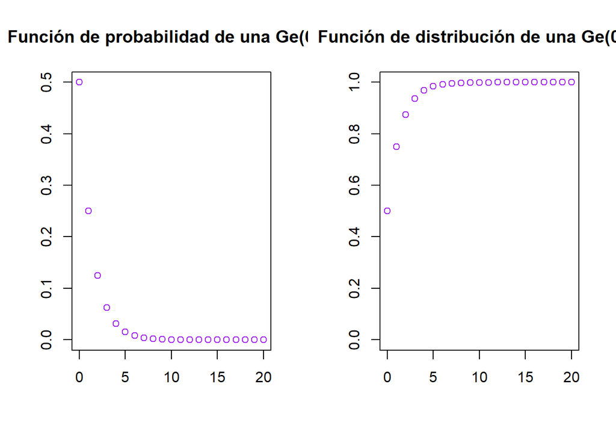

```r
par(mfrow = c(1,2))
plot(0:20, dgeom(0:20,0.5),col = "purple", xlab = "", ylab = "", main = "Función de probabilidad de una Ge(0.5)")
plot(0:20, pgeom(0:20,0.5),col = "purple", xlab = "", ylab = "", main = "Función de distribución de una Ge(0.5)", ylim = c(0,1))
```

```r
par(mfrow= c(1,1))
```

## Distribucion de Poisson

La V.A. $X$ se encarga de medir el numero de eventos en determinado tiempo y sigue la distribucion:
$$X\sim \text{Po}(\lambda)$$
Donde $\lambda$ es el numero de veces que ocurre el evento en el momento especificado. - El **dominio** de $X$ será $D_X = \{0,1,2,\dots\}$

- La **función de probabilidad** vendrá dada por
  $$f(k) = \frac{e^{-\lambda}\lambda^k}{k!}$$
- La **función de distribución** vendrá dada por
  $$F(x) = \left\{
  \begin{array}{cl}
  0 & \text{si } x<0
  \\ \sum_{k=0}^xf(k) & \text{si } 0\le x<n
  \\ 1 & \text{si } x\ge n
  \end{array}
  \right.$$
- **Esperanza** $E(X) = \lambda$
- **Varianza** $Var(X) = \lambda$

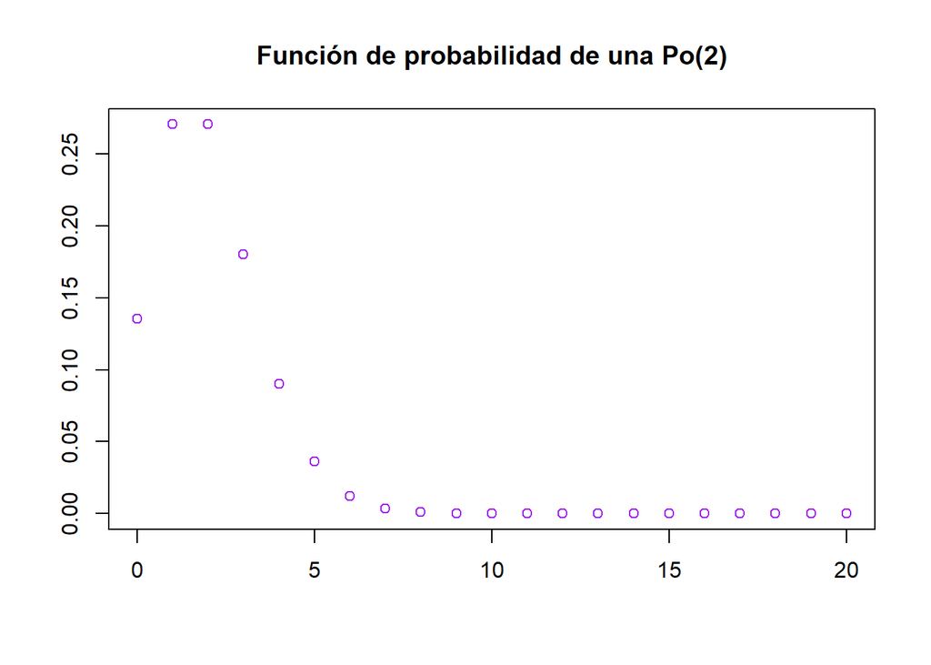

```r
plot(0:20, dpois(0:20,2),col = "purple", xlab = "", ylab = "", main = "Función de probabilidad de una Po(2)")
```

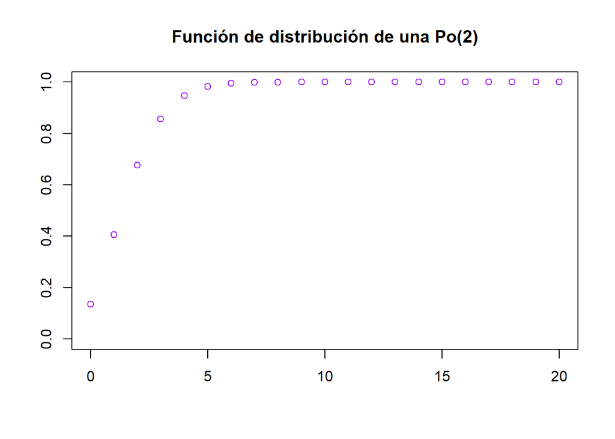

```r
plot(0:20, ppois(0:20,2),col = "purple", xlab = "", ylab = "", main = "Función de distribución de una Po(2)", ylim = c(0,1))
```

Ejemplo de $\lambda=5$

```r
l=5
x<-0:30
distr_poisson <- dpois(x,l)
distr_poisson
```

```
##  [1] 6.737947e-03 3.368973e-02 8.422434e-02 1.403739e-01 1.754674e-01
##  [6] 1.754674e-01 1.462228e-01 1.044449e-01 6.527804e-02 3.626558e-02
## [11] 1.813279e-02 8.242177e-03 3.434240e-03 1.320862e-03 4.717363e-04
## [16] 1.572454e-04 4.913920e-05 1.445271e-05 4.014640e-06 1.056484e-06
## [21] 2.641211e-07 6.288597e-08 1.429227e-08 3.107014e-09 6.472947e-10
## [26] 1.294589e-10 2.489595e-11 4.610361e-12 8.232787e-13 1.419446e-13
## [31] 2.365743e-14
```

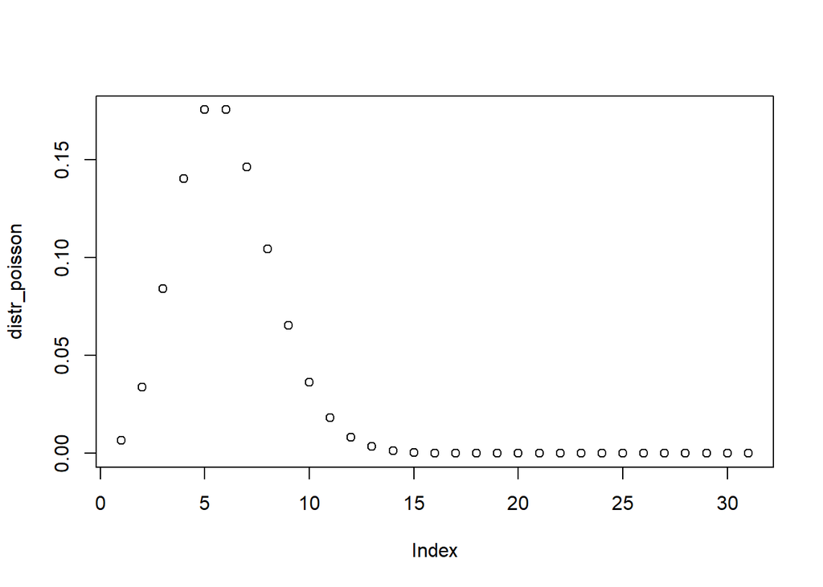

```r
plot(distr_poisson)
```

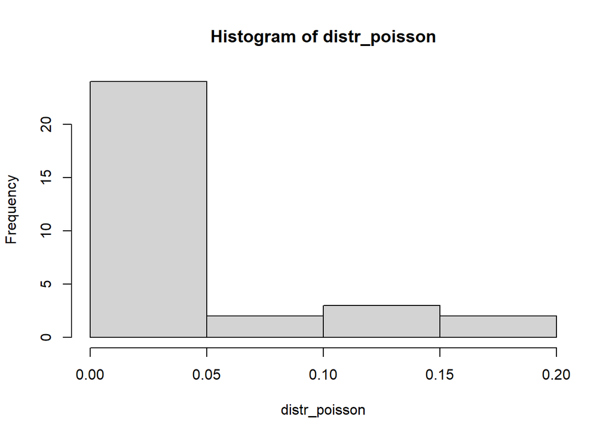

```r
hist(distr_poisson)
```

# Variable Aleatoria Continua

Una V.A. es continua cuando hay numeros continuos en $[0,1]$

**Función de densidad**

Función de densidad. Función $f:\mathbb{R}\longrightarrow\mathbb{R}$ que satisface

- $f(x)\ge 0\ \forall x\in\mathbb{R}$
- $\int_{-\infty}^{+\infty}f(t)dt=1$

Una función de densidad puede tener puntos de discontinuidad. Mientras el area bajo la curva sea de 1 estaremos hablando de una funcion de densidad.

## Esperanza

Esperanza de una v.a. continua. Sea $X$ v.a. continua con densidad $f_X$. La esperanza de $X$ es
$$E(X)=\int_{-\infty}^{+\infty}x\cdot f_X(x)dx$$

Si el dominio $D_X$ de $X$ es un intervalo de extremos $a<b$, entonces
$$E(X)=\int_a^b x\cdot f_X(x)dx$$

## Esperanza

Sea $g:D_X\longrightarrow \mathbb{R}$ una función continua. Entonces,

$$E(g(X)) = \int_{-\infty}^{+\infty}g(x)\cdot f_X(x)dx$$
Si el dominio $D_X$ de $X$ es un intervalo de extremos $a<b$, entonces
$$E(g(X))=\int_a^b g(x)\cdot f_X(x)dx$$

## Varianza

Varianza de una v.a. continua. Como en el caso discreto,
$$Var(X)=E((X-E(X))^2)$$

y se puede demostrar que

$$Var(X)=E(X^2)-(E(X))^2$$

## Distribuciones continuas

- [Uniforme](https://es.wikipedia.org/wiki/Distribución_uniforme_continua)
- [Exponencial](https://es.wikipedia.org/wiki/Distribución_exponencial)
- [Normal](https://es.wikipedia.org/wiki/Distribución_normal)
- [Khi cuadrado](https://es.wikipedia.org/wiki/Distribución_χ²)
- [t de Student](https://es.wikipedia.org/wiki/Distribución_t_de_Student)
- [F de Fisher](https://es.wikipedia.org/wiki/Distribución_F)

## Distribución Uniforme

Una V.A. continua es uniforme cuando tiene una distribucion sobre el intervalo real $[a,b]$ si $a<b$, entonces sigue $X\sim\text{U}(a,b)$
$$f_X(x)=\left\{
\begin{array}{rl}
\frac{1}{b-a} & \text{si } a\le x\le b
\\ 0 & \text{en cualquier otro caso}
\end{array}
\right.$$
Vemos que la probabilidad de estar en el intervalo es constante. - El **dominio** de $X$ será $D_X = [a,b]$

- La **función de distribución** vendrá dada por
  $$F_X(x)=\left\{
  \begin{array}{rl}
  0 & \text{si } x<a
  \\ \frac{x-a}{b-a} & \text{si } a\le x< b
  \\ 1 & \text{si } x\ge b
  \end{array}
  \right.$$
- **Esperanza** $E(X) = \frac{a+b}{2}$
- **Varianza** $Var(X) = \frac{(b-a)^2}{12}$

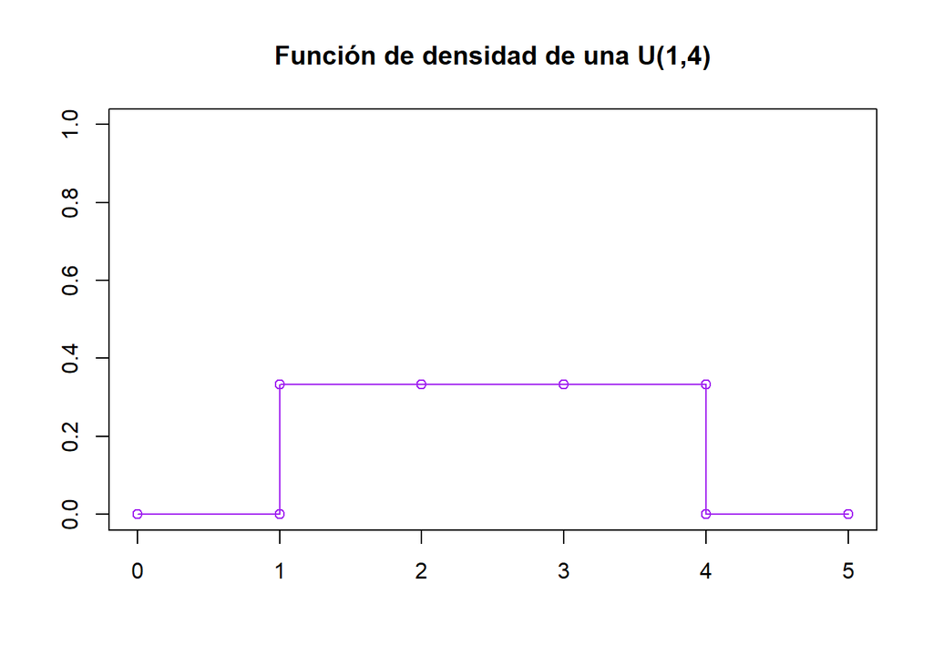

```r
plot(c(0,1,1:4,4,5), c(0,0,dunif(1:4,min = 1, max = 4),0,0),col = "purple", xlab = "", ylab = "", main = "Función de densidad de una U(1,4)", type = "o", ylim = c(0,1))
```

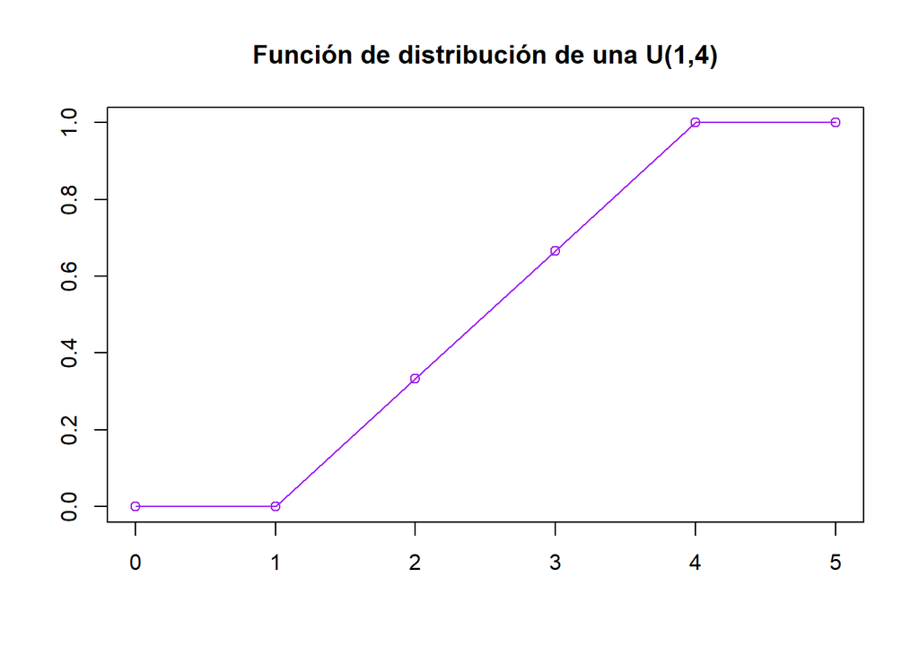

```r
plot(0:5, punif(0:5,min = 1, max = 4),col = "purple", xlab = "", ylab = "", main = "Función de distribución de una U(1,4)", type = "o")
```

Supongamos el clasico caso, $X\sim U(0,1)$, podemos modelar:

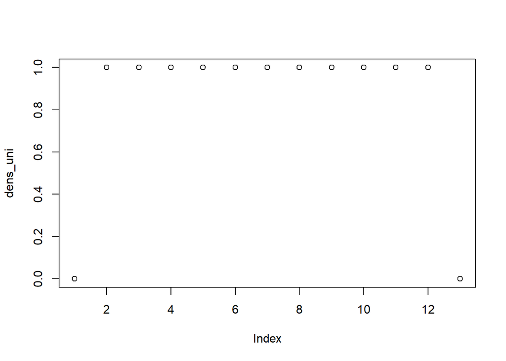

```r
a=0
b=1
q=0.5
x<-seq(-0.1,1.1,0.1)

dens_uni<-dunif(x,a,b)
distr_uni<-punif(x,a,b)
plot(dens_uni)
```

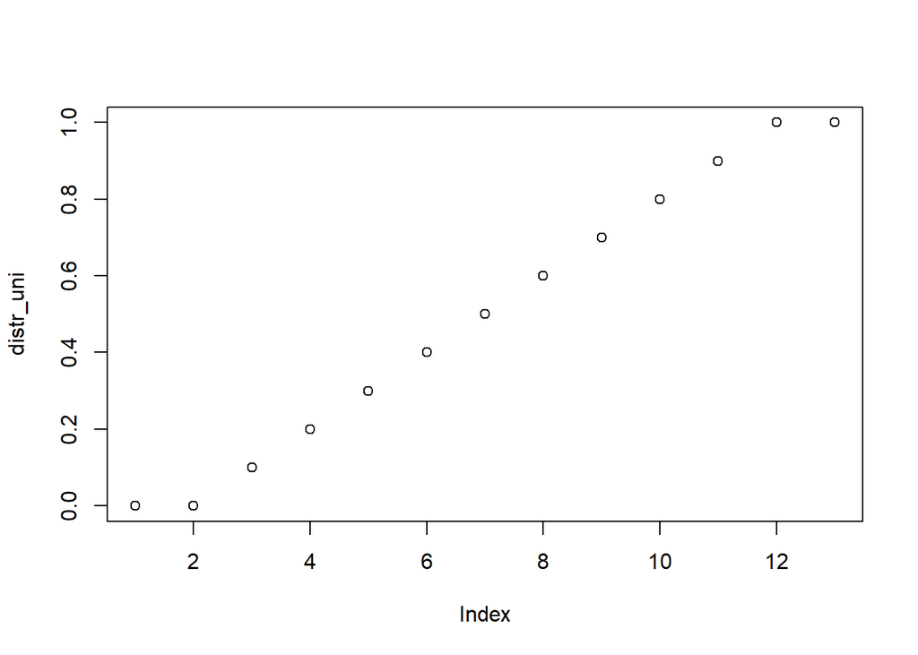

```r
plot(distr_uni)
```

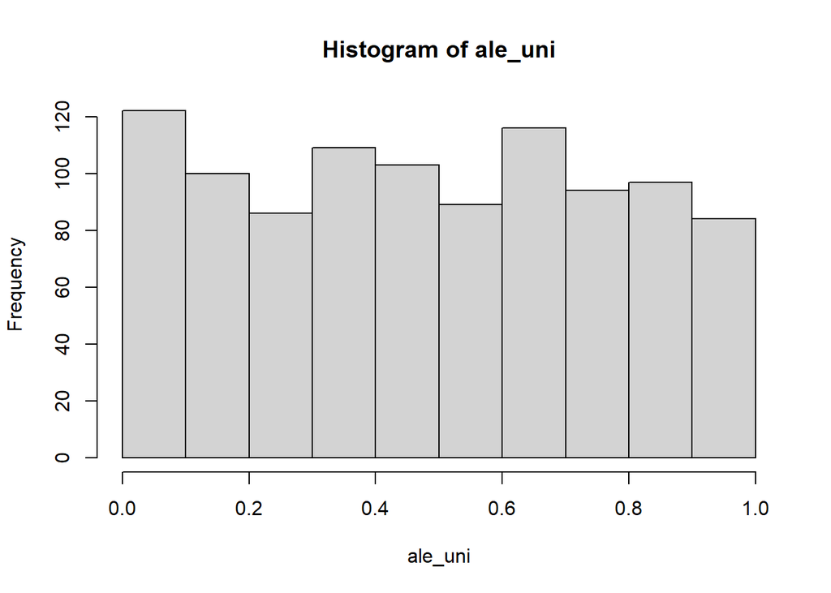

```r
runif(1000,a,b)->ale_uni
hist(ale_uni)
```